# NYPD Shooting Incident Data Report

Nezar Hindi

08/09/2024

List of every shooting incident that occurred in NYC going back to 2006 through the end of the previous calendar year.

This is a breakdown of every shooting incident that occurred in NYC going back to 2006 through the end of the previous calendar year. This data is manually extracted every quarter and reviewed by the Office of Management Analysis and Planning before being posted on the NYPD website. Each record represents a shooting incident in NYC and includes information about the event, the location and time of occurrence. In addition, information related to suspect and victim demographics is also included. This data can be used by the public to explore the nature of shooting/criminal activity. Please refer to [NYPD Shooting Incident Data (Historic) - CKAN](https://catalog.data.gov/dataset/nypd-shooting-incident-data-historic) for additional information about this dataset.

## Step 0: Import Library

```r
# install.packages("tidyverse")
library(tidyverse)
library(lubridate)
```

## Step 1: Load Data

- `read_csv()` reads comma delimited files, read_csv2() reads semicolon separated files (common in countries where , is used as the decimal place), read_tsv() reads tab delimited files, and read_delim() reads in files with any delimiter.

```r
df = read_csv("https://data.cityofnewyork.us/api/views/833y-fsy8/rows.csv?accessType=DOWNLOAD")
head(df)
```

```
## # A tibble: 6 × 21
##   INCIDENT_KEY OCCUR_DATE OCCUR_TIME BORO      LOC_OF_OCCUR_DESC PRECINCT
##          <dbl> <chr>      <time>     <chr>     <chr>                <dbl>
## 1    244608249 05/05/2022 00:10      MANHATTAN INSIDE                  14
## 2    247542571 07/04/2022 22:20      BRONX     OUTSIDE                 48
## 3     84967535 05/27/2012 19:35      QUEENS    <NA>                   103
## 4    202853370 09/24/2019 21:00      BRONX     <NA>                    42
## 5     27078636 02/25/2007 21:00      BROOKLYN  <NA>                    83
## 6    230311078 07/01/2021 23:07      MANHATTAN <NA>                    23
## # ℹ 15 more variables: JURISDICTION_CODE <dbl>, LOC_CLASSFCTN_DESC <chr>,
## #   LOCATION_DESC <chr>, STATISTICAL_MURDER_FLAG <lgl>, PERP_AGE_GROUP <chr>,
## #   PERP_SEX <chr>, PERP_RACE <chr>, VIC_AGE_GROUP <chr>, VIC_SEX <chr>,
## #   VIC_RACE <chr>, X_COORD_CD <dbl>, Y_COORD_CD <dbl>, Latitude <dbl>,
## #   Longitude <dbl>, Lon_Lat <chr>
```

## Step 2: Tidy and Transform Data

Let’s first eliminate the columns I do not need for this assignment, which are: **PRECINCT**,**JURISDICTION_CODE**,**LOCATION_DESC**, **X_COORD_CD**, **Y_COORD_CD**, and **Lon_Lat**.

```r
df_2 = df %>% select(INCIDENT_KEY,
                   OCCUR_DATE,
                   OCCUR_TIME,
                   BORO,
                   STATISTICAL_MURDER_FLAG,
                   PERP_AGE_GROUP,
                   PERP_SEX,
                   PERP_RACE,
                   VIC_AGE_GROUP,
                   VIC_SEX,
                   VIC_RACE,
                   Latitude,
                   Longitude)

# Return the column name along with the missing values
lapply(df_2, function(x) sum(is.na(x)))
```

```
## $INCIDENT_KEY
## [1] 0
##
## $OCCUR_DATE
## [1] 0
##
## $OCCUR_TIME
## [1] 0
##
## $BORO
## [1] 0
##
## $STATISTICAL_MURDER_FLAG
## [1] 0
##
## $PERP_AGE_GROUP
## [1] 9344
##
## $PERP_SEX
## [1] 9310
##
## $PERP_RACE
## [1] 9310
##
## $VIC_AGE_GROUP
## [1] 0
##
## $VIC_SEX
## [1] 0
##
## $VIC_RACE
## [1] 0
##
## $Latitude
## [1] 59
##
## $Longitude
## [1] 59
```

Understanding the reasons why data are missing is important for handling the remaining data correctly. There’s a fair amount of unidentifiable data on perpetrators (age, race, or sex.) Those cases are possibly still active and ongoing investigation. In fear of missing meaningful information, I handle this group of missing data by calling them as another group of “Unknown”.

Key observations on data type conversion are:

- **INCIDENT_KEY** should be treated as a string.
- **BORO** should be treated as a factor.
- **PERP_AGE_GROUP** should be treated as a factor.
- **PERP_SEX** should be treated as a factor.
- **PERP_RACE** should be treated as a factor.
- **VIC_AGE_GROUP** should be treated as a factor.
- **VIC_SEX** should be treated as a factor.
- **VIC_RACE** should be treated as a factor.

```r
# Tidy and transform data
df_2 = df_2 %>%
  replace_na(list(PERP_AGE_GROUP = "Unknown", PERP_SEX = "Unknown", PERP_RACE = "Unknown"))

# Remove extreme values in data
df_2 = subset(df_2, PERP_AGE_GROUP!="1020" & PERP_AGE_GROUP!="224" & PERP_AGE_GROUP!="940")

df_2$PERP_AGE_GROUP = recode(df_2$PERP_AGE_GROUP, UNKNOWN = "Unknown")
df_2$PERP_SEX = recode(df_2$PERP_SEX, U = "Unknown")
df_2$PERP_RACE = recode(df_2$PERP_RACE, UNKNOWN = "Unknown")
df_2$VIC_SEX   = recode(df_2$VIC_SEX, U = "Unknown")
df_2$VIC_RACE   = recode(df_2$VIC_RACE, UNKNOWN = "Unknown")
df_2$INCIDENT_KEY = as.character(df_2$INCIDENT_KEY)
df_2$BORO = as.factor(df_2$BORO)
df_2$PERP_AGE_GROUP = as.factor(df_2$PERP_AGE_GROUP)
df_2$PERP_SEX = as.factor(df_2$PERP_SEX)
df_2$PERP_RACE = as.factor(df_2$PERP_RACE)
df_2$VIC_AGE_GROUP = as.factor(df_2$VIC_AGE_GROUP)
df_2$VIC_SEX = as.factor(df_2$VIC_SEX)
df_2$VIC_RACE = as.factor(df_2$VIC_RACE)

# Return summary statistics
summary(df_2)
```

```
##  INCIDENT_KEY        OCCUR_DATE         OCCUR_TIME                  BORO
##  Length:28559       Length:28559       Length:28559      BRONX        : 8374
##  Class :character   Class :character   Class1:hms        BROOKLYN     :11345
##  Mode  :character   Mode  :character   Class2:difftime   MANHATTAN    : 3762
##                                        Mode  :numeric    QUEENS       : 4271
##                                                          STATEN ISLAND:  807
##
##
##  STATISTICAL_MURDER_FLAG PERP_AGE_GROUP     PERP_SEX              PERP_RACE
##  Mode :logical           Unknown:12492   (null) : 1141   BLACK         :11902
##  FALSE:23033             18-24  : 6438   F      :  444   Unknown       :11147
##  TRUE :5526              25-44  : 6041   M      :16165   WHITE HISPANIC: 2508
##                          <18    : 1682   Unknown:10809   BLACK HISPANIC: 1392
##                          (null) : 1141                   (null)        : 1141
##                          45-64  :  699                   WHITE         :  298
##                          (Other):   66                   (Other)       :  171
##  VIC_AGE_GROUP      VIC_SEX                                VIC_RACE
##  <18    : 2954   F      : 2760   AMERICAN INDIAN/ALASKAN NATIVE:   11
##  1022   :    1   M      :25787   ASIAN / PACIFIC ISLANDER      :  440
##  18-24  :10383   Unknown:   12   BLACK                         :20234
##  25-44  :12971                   BLACK HISPANIC                : 2795
##  45-64  : 1981                   Unknown                       :   70
##  65+    :  205                   WHITE                         :  728
##  UNKNOWN:   64                   WHITE HISPANIC                : 4281
##     Latitude       Longitude
##  Min.   :40.51   Min.   :-74.25
##  1st Qu.:40.67   1st Qu.:-73.94
##  Median :40.70   Median :-73.92
##  Mean   :40.74   Mean   :-73.91
##  3rd Qu.:40.82   3rd Qu.:-73.88
##  Max.   :40.91   Max.   :-73.70
##  NA's   :59      NA's   :59
```

## Step 3: Add Visualizations and Analysis

**Research Question**

1. Which part of New York has the most number of incidents? Of those incidents, how many are murder cases?

Brooklyn is the 1st in terms of the number of incidents, followed by Bronx and Queens respectively. Likewise, the number of murder cases follows the same pattern as that of incidents.

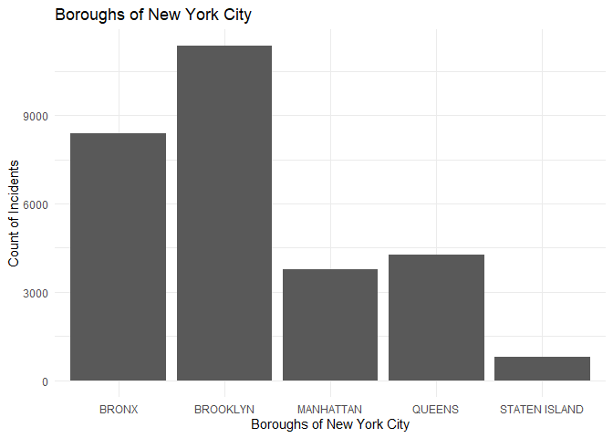

```r
g <- ggplot(df_2, aes(x = BORO)) +
  geom_bar() +
  labs(title = "Boroughs of New York City",
       x = "Boroughs of New York City",
       y = "Count of Incidents") +
  theme_minimal()
g
```

```r
table(df_2$BORO, df_2$STATISTICAL_MURDER_FLAG)
```

```
##
##                 FALSE TRUE
##   BRONX          6740 1634
##   BROOKLYN       9135 2210
##   MANHATTAN      3090  672
##   QUEENS         3431  840
##   STATEN ISLAND   637  170
```

2. Which day and time should people in New York be cautious of falling into victims of crime?
- Weekends in NYC have the most chances of incidents. Be cautious!
- Incidents historically happen in the evening and night time. If there’s nothing urgent, recommend people staying at home!

```r
df_2$OCCUR_DAY = mdy(df_2$OCCUR_DATE)
df_2$OCCUR_DAY = wday(df_2$OCCUR_DAY, label = TRUE)
df_2$OCCUR_HOUR = hour(hms(as.character(df_2$OCCUR_TIME)))

df_3 = df_2 %>%
  group_by(OCCUR_DAY) %>%
  count()

df_4 = df_2 %>%
  group_by(OCCUR_HOUR) %>%
  count()
```

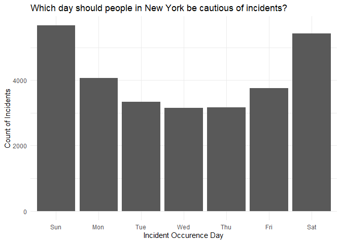

```r
g <- ggplot(df_3, aes(x = OCCUR_DAY, y = n)) +
  geom_col() +
  labs(title = "Which day should people in New York be cautious of incidents?",
       x = "Incident Occurence Day",
       y = "Count of Incidents") +
  theme_minimal()
g
```

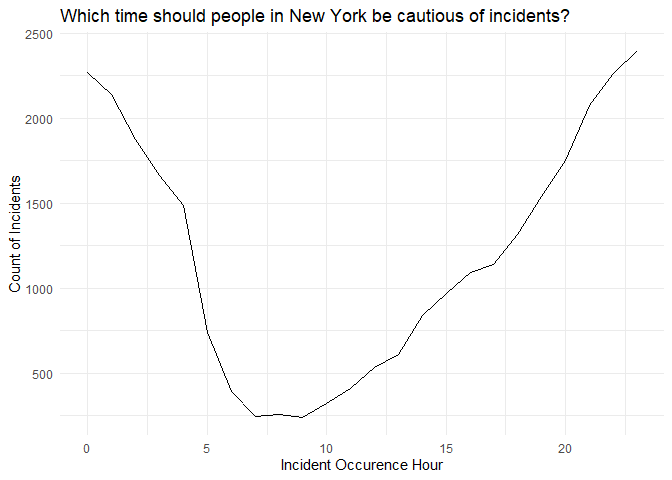

```r
g <- ggplot(df_4, aes(x = OCCUR_HOUR, y = n)) +
  geom_line() +
  labs(title = "Which time should people in New York be cautious of incidents?",
       x = "Incident Occurence Hour",
       y = "Count of Incidents") +
  theme_minimal()
g
```

3. The Profile of Perpetrators and Victims
- There’s a striking number of incidents in the age group of 25-44 and 18-24.
- Black and White Hispanic stood out in the number of incidents in Boroughs of New York City.
- There are significantly more incidents with Male than those of Female.

```r
table(df_2$PERP_AGE_GROUP, df_2$VIC_AGE_GROUP)
```

```
##
##            <18 1022 18-24 25-44 45-64  65+ UNKNOWN
##   (null)   106    0   311   619    96    9       0
##   <18      521    0   652   413    79   15       2
##   1028       0    0     0     1     0    0       0
##   18-24    808    1  2841  2394   335   47      12
##   25-44    270    0  1560  3600   524   49      38
##   45-64     21    0    85   373   202   13       5
##   65+        0    0     2    27    24   12       0
##   Unknown 1228    0  4932  5544   721   60       7
```

```r
table(df_2$PERP_SEX, df_2$VIC_SEX)
```

```
##
##               F     M Unknown
##   (null)    123  1018       0
##   F          77   366       1
##   M        1755 14403       7
##   Unknown   805 10000       4
```

```r
table(df_2$PERP_RACE, df_2$VIC_RACE)
```

```
##
##                                  AMERICAN INDIAN/ALASKAN NATIVE
##   (null)                                                      1
##   AMERICAN INDIAN/ALASKAN NATIVE                              0
##   ASIAN / PACIFIC ISLANDER                                    0
##   BLACK                                                       4
##   BLACK HISPANIC                                              0
##   Unknown                                                     5
##   WHITE                                                       0
##   WHITE HISPANIC                                              1
##
##                                  ASIAN / PACIFIC ISLANDER BLACK BLACK HISPANIC
##   (null)                                               27   795            115
##   AMERICAN INDIAN/ALASKAN NATIVE                        0     2              0
##   ASIAN / PACIFIC ISLANDER                             61    56             14
##   BLACK                                               164  9410            839
##   BLACK HISPANIC                                       20   561            365
##   Unknown                                             113  8523            999
##   WHITE                                                13    42             23
##   WHITE HISPANIC                                       42   845            440
##
##                                  Unknown WHITE WHITE HISPANIC
##   (null)                               1    20            182
##   AMERICAN INDIAN/ALASKAN NATIVE       0     0              0
##   ASIAN / PACIFIC ISLANDER             0    12             26
##   BLACK                               25   205           1255
##   BLACK HISPANIC                       6    36            404
##   Unknown                             25   187           1295
##   WHITE                                1   165             54
##   WHITE HISPANIC                      12   103           1065
```

4. Building logistic regression model to predict if the incident is likely a murder case or not?

Logistic regression is an instance of classification technique that you can use to predict a qualitative response. I will use logistic regression models to estimate the probability that a murder case belongs to a particular profile, location, or date & time.

```r
# Logistics Regression
glm.fit <- glm(STATISTICAL_MURDER_FLAG ~ PERP_RACE + PERP_SEX + PERP_AGE_GROUP + OCCUR_HOUR + OCCUR_DAY + Latitude + Longitude, data = df_2, family = binomial)
summary(glm.fit)
```

```
##
## Call:
## glm(formula = STATISTICAL_MURDER_FLAG ~ PERP_RACE + PERP_SEX +
##     PERP_AGE_GROUP + OCCUR_HOUR + OCCUR_DAY + Latitude + Longitude,
##     family = binomial, data = df_2)
##
## Coefficients: (2 not defined because of singularities)
##                                           Estimate Std. Error z value Pr(>|z|)
## (Intercept)                             45.1815985 19.5063323   2.316 0.020544
## PERP_RACEAMERICAN INDIAN/ALASKAN NATIVE -8.9102418 84.3157576  -0.106 0.915839
## PERP_RACEASIAN / PACIFIC ISLANDER        0.9799126  0.2820228   3.475 0.000512
## PERP_RACEBLACK                           0.5952693  0.2252821   2.642 0.008234
## PERP_RACEBLACK HISPANIC                  0.5261928  0.2343597   2.245 0.024753
## PERP_RACEUnknown                         0.1176946  0.0880966   1.336 0.181558
## PERP_RACEWHITE                           1.1343621  0.2567736   4.418 9.97e-06
## PERP_RACEWHITE HISPANIC                  0.7560751  0.2294603   3.295 0.000984
## PERP_SEXF                               -2.4513604  0.2636102  -9.299  < 2e-16
## PERP_SEXM                               -2.6219203  0.2393219 -10.956  < 2e-16
## PERP_SEXUnknown                                 NA         NA      NA       NA
## PERP_AGE_GROUP<18                        2.2221740  0.1697017  13.095  < 2e-16
## PERP_AGE_GROUP18-24                      2.4155071  0.1601275  15.085  < 2e-16
## PERP_AGE_GROUP25-44                      2.7218228  0.1600585  17.005  < 2e-16
## PERP_AGE_GROUP45-64                      3.0940024  0.1768525  17.495  < 2e-16
## PERP_AGE_GROUP65+                        3.1212486  0.3035676  10.282  < 2e-16
## PERP_AGE_GROUPUnknown                           NA         NA      NA       NA
## OCCUR_HOUR                              -0.0008956  0.0018749  -0.478 0.632863
## OCCUR_DAY.L                             -0.0417565  0.0376201  -1.110 0.267020
## OCCUR_DAY.Q                             -0.0666429  0.0402729  -1.655 0.097969
## OCCUR_DAY.C                             -0.0470149  0.0406188  -1.157 0.247082
## OCCUR_DAY^4                             -0.0039996  0.0413188  -0.097 0.922887
## OCCUR_DAY^5                              0.0254458  0.0434289   0.586 0.557930
## OCCUR_DAY^6                             -0.0861353  0.0445919  -1.932 0.053405
## Latitude                                -0.3519397  0.1795728  -1.960 0.050011
## Longitude                                0.4407163  0.2301238   1.915 0.055476
##
## (Intercept)                             *
## PERP_RACEAMERICAN INDIAN/ALASKAN NATIVE
## PERP_RACEASIAN / PACIFIC ISLANDER       ***
## PERP_RACEBLACK                          **
## PERP_RACEBLACK HISPANIC                 *
```

[output cut: 17 more lines]

```
## OCCUR_DAY^5
## OCCUR_DAY^6                             .
## Latitude                                .
## Longitude                               .
## ---
## Signif. codes:  0 '***' 0.001 '**' 0.01 '*' 0.05 '.' 0.1 ' ' 1
##
## (Dispersion parameter for binomial family taken to be 1)
##
##     Null deviance: 28022  on 28499  degrees of freedom
## Residual deviance: 27055  on 28476  degrees of freedom
##   (59 observations deleted due to missingness)
## AIC: 27103
##
## Number of Fisher Scoring iterations: 9
```

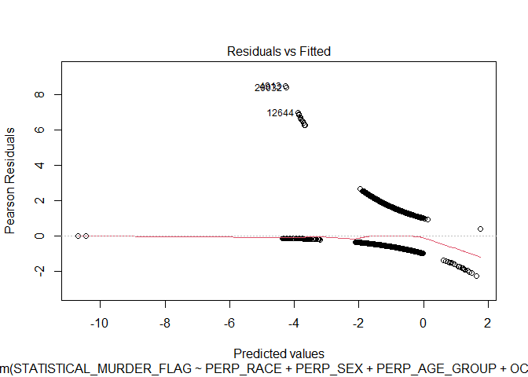

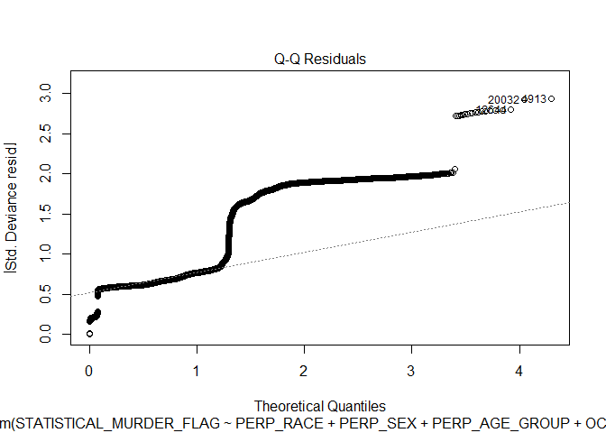

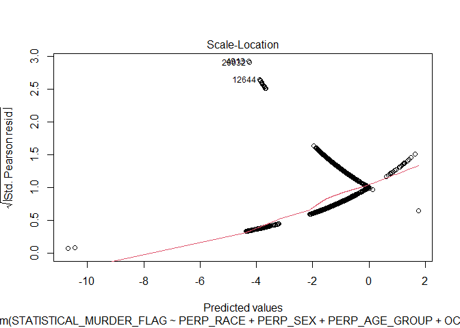

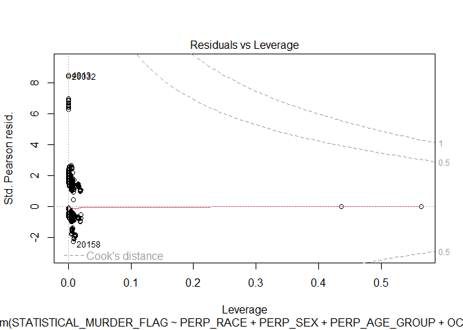

```r
plot(glm.fit)
```